# Virome and Clinical Metadata Analysis

```r
# load libraries
library(here)
library(data.table)
library(stringr)
library(dplyr)
library(tidyr)
library(ggplot2)
library(readxl)
library(ggpubr)
source(here::here("src/parse_sample_id.R"))
```

Load and parse metadata

```r
meta_pil_dt <- read_excel(
  here::here("metadata/samples/brain_pilot_fmt_pools_metadata.xlsx")
) |>
  mutate(
    condition = case_when(
      grepl("-A", sample_ID) ~ "bulk DNA",
      grepl("-B", sample_ID) ~ "host depleted DNA",
      grepl("-C", sample_ID) ~ "bulk RNA",
      TRUE ~ "other"
    )
  ) |>
  mutate(tissue = gsub("Brain tissue/", "", sample_description)) |>
  filter(condition %in% c("bulk DNA", "other")) #only look at hybrid capture DNA for this

meta_hvp_dt <- read_excel(
  here::here("metadata/samples/brain_hvp_fmt_pools_metadata.xlsx")
) |>
  mutate(tissue = gsub("Brain DNA - ", "", sample_description)) |>
  filter(note == "brain_dna_capture") #only look at hybrid capture DNA for this

meta_dt <- rbind(
  meta_pil_dt |> select(c(sample_ID, Pool, tissue)),
  meta_hvp_dt |> select(c(sample_ID, Pool, tissue))
) |>
  mutate(
    mlab2 = case_when(
      grepl("XX-0", sample_ID) ~ str_replace(sample_ID, "^([^-]*-[^-]*).*$", "\\1"),
      #grepl("HELTHY|MODAD|SEVAD", sample_ID) ~ gsub("-A$", "", sample_ID),
      TRUE ~ sample_ID
    )
  ) |>
  filter(!grepl("CMMR", sample_ID))
```

```r
donor_meta_dt <- read_excel(
  here::here("metadata/donors/simple_donor_meta1.xlsx")
)

# The donor sheet has a few `join_col` keys that appear more than once and map to
# DIFFERENT patient_IDs/ages (ambiguous source data). Left unhandled, merge()
# would fan those sample rows out into duplicates. De-duplicate to keep the join
# 1:1 on join_col (keeping the first occurrence) and report the affected keys so
# they can be fixed upstream.
dup_join <- unique(donor_meta_dt$join_col[duplicated(donor_meta_dt$join_col)])
if (length(dup_join)) {
  message("Ambiguous donor join_col keys collapsed to first row: ",
          paste(dup_join, collapse = ", "))
}
donor_meta_dt <- donor_meta_dt |> distinct(join_col, .keep_all = TRUE)

all_meta_dt <- merge(
  meta_dt,
  donor_meta_dt,
  by.x = "mlab2",
  by.y = "join_col",
  all = T
)
```

load tax tables

```r
tax_file_list <- c(
  here::here("data/tax_profiles/esviritu_p2055.tax_profile.tsv"),
  here::here("data/tax_profiles/esviritu_p2058.tax_profile.tsv"),
  here::here("data/tax_profiles/esviritu_p2059.tax_profile.tsv"),
  here::here("data/tax_profiles/esviritu_p1733.tax_profile.tsv"),
  here::here("data/tax_profiles/esviritu_p1849.tax_profile.tsv"),
  here::here("data/tax_profiles/esviritu_p1894.tax_profile.tsv")
)


esv_tax_dt <- rbindlist(lapply(tax_file_list, fread))

esv_tax_dt <- esv_tax_dt |>
  filter(
    read_count >= 10,
    !genus %in% c(
      "g__Betacoronavirus", "g__Gammaretrovirus", "g__Respirovirus",
      "g__Lentivirus", "g__Alphacoronavirus", "g__Orthorubulavirus",
      "g__Enterovirus"
      ),
    !species %in% c(
      "s__Betapapillomavirus 1", "s__Betapapillomavirus 2",
      "s__Betapapillomavirus 3", "s__Human papillomavirus",
      "s__Triatovirus nigereginacellulae", "s__Lepidopteran ambidensovirus 1",
      "s__Scythevirus dianchis", "s__Blattambidensovirus incertum1",
      "s__Pigeon aviadenovirus B", "s__Alphainfluenzavirus influenzae"
      ),
    !grepl("s__unclassified", species)
    ) |>
  separate(sample_ID, c("sample_ID", "Pool"), sep = "[.]")
```

```r
esv_tax_dt |>
  distinct(species)
```

| species |
| --- |
| s__Simplexvirus humanalpha1 |
| s__Alphatorquevirus homin13 |
| s__TTV-like mini virus |
| s__Torque teno virus |
| s__Gammapapillomavirus 8 |
| s__Dependoparvovirus primate1 |
| s__Erythroparvovirus primate1 |
| s__Lymphocryptovirus humangamma4 |
| s__Gammatorquevirus homidi14 |
| s__Roseolovirus humanbeta6b |

[output cut: 41 more lines]

merge metadata and tax profiles

```r
merge_dt <- merge(
  esv_tax_dt,
  all_meta_dt,
  by = c("sample_ID", "Pool"),
  all.y = T
) |>
  filter(!grepl("CMMR", sample_ID)) # remove controls
```

# Virome ~ metadata association analysis

## QC: build a clean, one-row-per-sample analysis table

We work at the level of the sequenced sample (a brain region from a donor). Samples with no virus passing the filters are TRUE negatives and are kept as zeros (they still contribute to prevalence denominators).

```r
# one row per real sample, with complete donor/tissue metadata
sample_meta <- all_meta_dt |>
  filter(!is.na(sample_ID), !grepl("CMMR", sample_ID)) |>
  # collapse any duplicate (sample_ID, Pool) rows to one row per sample
  distinct(sample_ID, Pool, .keep_all = TRUE) |>
  transmute(
    sample_ID, Pool,
    donor        = patient_ID,
    tissue       = factor(tissue),
    AD_status    = factor(AD_status, levels = c("NO", "YES")),
    age_at_death = as.numeric(age_at_death)
  )

n_samples <- nrow(sample_meta)

# confirm the analysis set has NO missing metadata
missing_report <- colSums(is.na(sample_meta))
missing_report
```

```
   sample_ID         Pool        donor       tissue    AD_status age_at_death
           0            0            0            0            0            0
```

```r
# how many samples are viral-negative (no species passes filters)?
n_negative <- sum(!sample_meta$sample_ID %in% esv_tax_dt$sample_ID)
c(n_samples = n_samples, n_viral_negative = n_negative)
```

```
       n_samples n_viral_negative
             249               42
```

```r
# structure: regions per donor (repeated measures live in the 3-region donors)
table(regions_per_donor = table(sample_meta$donor))
```

```
regions_per_donor
 1  2  3
19 10 70
```

## Focus on the most common virus species

“Most common” = detected in at least `min_detect` samples. Everything below the threshold is too sparse for a stable association test.

```r
# collapse subspecies rows to one abundance per (sample, species)
det <- esv_tax_dt |>
  semi_join(sample_meta, by = c("sample_ID", "Pool")) |>
  group_by(sample_ID, Pool, species) |>
  summarise(RPKMF = sum(RPKMF), .groups = "drop")

min_detect <- 10  # tune this threshold

prevalence_tbl <- det |>
  distinct(sample_ID, Pool, species) |>
  count(species, name = "n_detected") |>
  mutate(prevalence = round(n_detected / n_samples, 3)) |>
  arrange(desc(n_detected))

focal_species <- prevalence_tbl |> filter(n_detected >= min_detect)
focal_species
```

| species | n_detected | prevalence |
| --- | --- | --- |
| s__Erythroparvovirus primate1 | 126 | 0.506 |
| s__Torque teno virus | 61 | 0.245 |
| s__Roseolovirus humanbeta6b | 42 | 0.169 |
| s__Lymphocryptovirus humangamma4 | 28 | 0.112 |
| s__Alphapolyomavirus quintihominis | 16 | 0.064 |
| s__Dependoparvovirus primate1 | 15 | 0.060 |
| s__TTV-like mini virus | 14 | 0.056 |
| s__Adeno-associated virus | 11 | 0.044 |
| s__Roseolovirus humanbeta6a | 11 | 0.044 |
| s__Simplexvirus humanalpha1 | 10 | 0.040 |

```r
# presence/absence + abundance for every sample x focal species
pa <- tidyr::crossing(sample_meta, species = focal_species$species) |>
  left_join(det, by = c("sample_ID", "Pool", "species")) |>
  mutate(
    present   = as.integer(!is.na(RPKMF)),
    RPKMF     = ifelse(is.na(RPKMF), 0, RPKMF),
    sp_short  = gsub("^s__", "", species)
  )
```

## Descriptive prevalence plots

[figure not shown]

```r
ggsave(
  here::here("charts/AD_status_virus_prev_col1.pdf"),
  ad_prev_p,
  width = 5,
  height = 4
)
```

```r
ggsave(
  here::here("charts/brain_tissue_virus_prev_col1.pdf"),
  tissue_prev_p,
  width = 5,
  height = 4
)
```

## Association testing

Three complementary tests per species, FDR-corrected (Benjamini-Hochberg) across species within each variable:

- **tissue** — sample-level variable, tested with Fisher’s exact test on presence x region.
- **AD_status / age_at_death** — donor-level variables. Because most donors contribute >1 sample, we test these two ways:
  - **(A) donor aggregation** — collapse to one observation per donor (present if detected in ANY region), then Fisher (AD) / logistic (age).
  - **(B) mixed-effects GLMM** — sample-level logistic regression with a random intercept per donor, adjusting AD, age, and tissue simultaneously.

```r
library(purrr)
library(broom)
library(lme4)
library(broom.mixed)
```

### Tissue (sample level)

```r
tissue_res <- map_dfr(focal_species$species, function(sp) {
  d  <- filter(pa, species == sp)
  ft <- fisher.test(table(d$tissue, d$present),
                    simulate.p.value = TRUE, B = 1e4)
  tibble(species = gsub("^s__", "", sp), test = "Fisher presence~tissue",
         p.value = ft$p.value)
}) |>
  mutate(p.adj = p.adjust(p.value, "BH")) |>
  arrange(p.value)
tissue_res
```

| species | test | p.value | p.adj |
| --- | --- | --- | --- |
| Adeno-associated virus | Fisher presence~tissue | 0.00439956 | 0.0439956 |
| Roseolovirus humanbeta6a | Fisher presence~tissue | 0.04979502 | 0.2489751 |
| Alphapolyomavirus quintihominis | Fisher presence~tissue | 0.15468453 | 0.5156151 |
| Roseolovirus humanbeta6b | Fisher presence~tissue | 0.29267073 | 0.7316768 |
| TTV-like mini virus | Fisher presence~tissue | 0.41505849 | 0.7916351 |
| Erythroparvovirus primate1 | Fisher presence~tissue | 0.50214979 | 0.7916351 |
| Dependoparvovirus primate1 | Fisher presence~tissue | 0.55414459 | 0.7916351 |
| Simplexvirus humanalpha1 | Fisher presence~tissue | 0.69743026 | 0.7933651 |
| Lymphocryptovirus humangamma4 | Fisher presence~tissue | 0.71402860 | 0.7933651 |
| Torque teno virus | Fisher presence~tissue | 0.86841316 | 0.8684132 |

### AD status & age — (A) donor-aggregated

```r
donor_pa <- pa |>
  group_by(donor, species, AD_status, age_at_death) |>
  summarise(present = as.integer(any(present == 1)), .groups = "drop")

donor_res <- map_dfr(focal_species$species, function(sp) {
  d  <- filter(donor_pa, species == sp)
  ft <- fisher.test(table(d$AD_status, d$present))         # AD: donor-level OR
  gl <- glm(present ~ age_at_death, data = d, family = binomial)  # age
  age_row <- coef(summary(gl))["age_at_death", ]
  tibble(
    species       = gsub("^s__", "", sp),
    AD_OR         = unname(ft$estimate),
    AD_p          = ft$p.value,
    age_OR_per_yr = unname(exp(coef(gl)["age_at_death"])),
    age_p         = unname(age_row["Pr(>|z|)"])
  )
}) |>
  mutate(AD_p.adj  = p.adjust(AD_p,  "BH"),
         age_p.adj = p.adjust(age_p, "BH")) |>
  arrange(AD_p)
donor_res
```

| species | AD_OR | AD_p | age_OR_per_yr | age_p | AD_p.adj | age_p.adj |
| --- | --- | --- | --- | --- | --- | --- |
| TTV-like mini virus | 0.4115492 | 0.2349444 | 0.9607613 | 0.2741800 | 1 | 0.6638353 |
| Dependoparvovirus primate1 | 0.4736686 | 0.3832219 | 0.9434391 | 0.1403629 | 1 | 0.5630229 |
| Erythroparvovirus primate1 | 1.4753195 | 0.4529146 | 1.0353011 | 0.1689069 | 1 | 0.5630229 |
| Simplexvirus humanalpha1 | 0.5869138 | 0.6207852 | 1.0030905 | 0.9489250 | 1 | 0.9914402 |
| Roseolovirus humanbeta6b | 0.7646885 | 0.6212641 | 0.9997411 | 0.9914402 | 1 | 0.9914402 |
| Adeno-associated virus | 2.5686072 | 0.6804760 | 1.0703966 | 0.1058502 | 1 | 0.5630229 |
| Alphapolyomavirus quintihominis | 1.5841766 | 0.7270483 | 1.0357298 | 0.3319177 | 1 | 0.6638353 |
| Lymphocryptovirus humangamma4 | 0.9603989 | 1.0000000 | 0.9989530 | 0.9701785 | 1 | 0.9914402 |
| Roseolovirus humanbeta6a | 1.0645469 | 1.0000000 | 1.0313154 | 0.4474923 | 1 | 0.7458205 |
| Torque teno virus | 0.9752344 | 1.0000000 | 1.0079653 | 0.7437239 | 1 | 0.9914402 |

### AD status & age — (B) mixed-effects GLMM

Model: `present ~ AD_status + scale(age) + tissue + (1 | donor)`. Most donors contribute multiple brain regions (70 of 99 donors have all 3), so the per-donor random intercept is important here to absorb within-donor correlation and avoid pseudo-replication.

**Sparse species cause complete separation** (huge or vanishingly small SEs and spurious p ~ 0). We therefore (a) only fit the GLMM to species with enough detections, and (b) flag any remaining fit whose SE is implausible as unreliable and exclude it from FDR correction.

```r
glmm_min_detect <- 25  # GLMM needs a reasonable number of positives

glmm_species <- focal_species |> filter(n_detected >= glmm_min_detect) |> pull(species)

glmm_res <- map_dfr(glmm_species, function(sp) {
  d <- filter(pa, species == sp)
  m <- tryCatch(
    glmer(present ~ AD_status + scale(age_at_death) + tissue + (1 | donor),
          data = d, family = binomial,
          control = glmerControl(optimizer = "bobyqa",
                                  optCtrl = list(maxfun = 2e5))),
    error = function(e) NULL
  )
  if (is.null(m)) {
    return(tibble(species = gsub("^s__", "", sp),
                  term = c("AD_statusYES", "scale(age_at_death)"),
                  estimate = NA_real_, std.error = NA_real_, p.value = NA_real_))
  }
  broom.mixed::tidy(m, effects = "fixed") |>
    filter(term %in% c("AD_statusYES", "scale(age_at_death)")) |>
    transmute(species = gsub("^s__", "", sp), term, estimate, std.error, p.value)
}) |>
  # guard against separation: trust only plausibly-scaled SEs
  mutate(reliable = is.finite(std.error) & std.error > 0.05 & std.error < 5) |>
  group_by(term) |>
  mutate(p.adj = ifelse(reliable, p.adjust(ifelse(reliable, p.value, NA), "BH"), NA_real_)) |>
  ungroup() |>
  arrange(term, p.value)
glmm_res
```

| species | term | estimate | std.error | p.value | reliable | p.adj |
| --- | --- | --- | --- | --- | --- | --- |
| Roseolovirus humanbeta6b | AD_statusYES | -0.45783465 | 0.4650662 | 0.3248941 | TRUE | 0.9331422 |
| Erythroparvovirus primate1 | AD_statusYES | 0.42779443 | 0.5875737 | 0.4665711 | TRUE | 0.9331422 |
| Torque teno virus | AD_statusYES | 0.37070929 | 1.7380797 | 0.8311033 | TRUE | 0.9542831 |
| Lymphocryptovirus humangamma4 | AD_statusYES | -0.07546279 | 1.3163091 | 0.9542831 | TRUE | 0.9542831 |
| Erythroparvovirus primate1 | scale(age_at_death) | 0.29242972 | 0.2398474 | 0.2227560 | TRUE | 0.5367040 |
| Roseolovirus humanbeta6b | scale(age_at_death) | 0.22643988 | 0.2045776 | 0.2683520 | TRUE | 0.5367040 |
| Torque teno virus | scale(age_at_death) | 0.29135312 | 0.8630479 | 0.7356750 | TRUE | 0.9092827 |
| Lymphocryptovirus humangamma4 | scale(age_at_death) | -0.05929851 | 0.5204211 | 0.9092827 | TRUE | 0.9092827 |

### Combined summary

```r
summary_tbl <- donor_res |>
  select(species, AD_OR, AD_p.adj, age_OR_per_yr, age_p.adj) |>
  left_join(
    glmm_res |>
      pivot_wider(id_cols = species, names_from = term,
                  values_from = c(estimate, p.adj)),
    by = "species"
  ) |>
  left_join(tissue_res |> select(species, tissue_p.adj = p.adj),
            by = "species") |>
  arrange(AD_p.adj)
summary_tbl
```

| species | AD_OR | AD_p.adj | age_OR_per_yr | age_p.adj | estimate_AD_statusYES | estimate_scale(age_at_death) | p.adj_AD_statusYES | p.adj_scale(age_at_death) | tissue_p.adj |
| --- | --- | --- | --- | --- | --- | --- | --- | --- | --- |
| TTV-like mini virus | 0.4115492 | 1 | 0.9607613 | 0.6638353 | NA | NA | NA | NA | 0.7916351 |
| Dependoparvovirus primate1 | 0.4736686 | 1 | 0.9434391 | 0.5630229 | NA | NA | NA | NA | 0.7916351 |
| Erythroparvovirus primate1 | 1.4753195 | 1 | 1.0353011 | 0.5630229 | 0.42779443 | 0.29242972 | 0.9331422 | 0.5367040 | 0.7916351 |
| Simplexvirus humanalpha1 | 0.5869138 | 1 | 1.0030905 | 0.9914402 | NA | NA | NA | NA | 0.7933651 |
| Roseolovirus humanbeta6b | 0.7646885 | 1 | 0.9997411 | 0.9914402 | -0.45783465 | 0.22643988 | 0.9331422 | 0.5367040 | 0.7316768 |
| Adeno-associated virus | 2.5686072 | 1 | 1.0703966 | 0.5630229 | NA | NA | NA | NA | 0.0439956 |
| Alphapolyomavirus quintihominis | 1.5841766 | 1 | 1.0357298 | 0.6638353 | NA | NA | NA | NA | 0.5156151 |
| Lymphocryptovirus humangamma4 | 0.9603989 | 1 | 0.9989530 | 0.9914402 | -0.07546279 | -0.05929851 | 0.9542831 | 0.9092827 | 0.7933651 |
| Roseolovirus humanbeta6a | 1.0645469 | 1 | 1.0313154 | 0.7458205 | NA | NA | NA | NA | 0.2489751 |
| Torque teno virus | 0.9752344 | 1 | 1.0079653 | 0.9914402 | 0.37070929 | 0.29135312 | 0.9542831 | 0.9092827 | 0.8684132 |

## Abundance-based tests (two-part / hurdle framing)

Viral abundance is zero-inflated, so we treat it as a **two-part (hurdle)** process and keep the two parts separate:

- **Part 1 - prevalence:** is the virus *detected* at different rates? This is already covered by the presence/absence tests above (Fisher / GLMM).
- **Part 2 - load given presence:** *among samples where the virus is detected*, is the abundance (`RPKMF`) higher? This is the section below. We drop zeros here **on purpose** so this arm reflects load only, not prevalence.

**Caveat (selection / collider bias):** conditioning on detection means the positive subgroups being compared are not the full randomised groups; if a variable also shifts prevalence, the conditional-load comparison can be biased. The conditional estimand is “among infected samples,” which is a valid but narrower question. To make the logic transparent we therefore **also run unconditional tests that include the zeros** (see the sensitivity subsection at the end); those combine prevalence + load into a single abundance shift.

Donor-level variables (AD, age) are aggregated to the mean per-donor abundance to respect the repeated-measures structure.

```r
# positive samples only, with abundance
pos <- pa |> filter(present == 1)

# donor-level mean abundance among positive samples (for AD/age)
donor_abund <- pos |>
  group_by(donor, species, sp_short, AD_status, age_at_death) |>
  summarise(mean_RPKMF = mean(RPKMF), .groups = "drop")
```

### Tissue - Kruskal-Wallis on abundance (positive samples)

```r
abund_tissue_res <- map_dfr(focal_species$species, function(sp) {
  d <- filter(pos, species == sp)
  # need >=2 regions each with >=2 positive samples for a meaningful test
  ok <- d |> count(tissue) |> filter(n >= 2) |> nrow()
  if (ok < 2) {
    return(tibble(species = gsub("^s__", "", sp), n_pos = nrow(d),
                  p.value = NA_real_))
  }
  kw <- kruskal.test(RPKMF ~ tissue, data = d)
  tibble(species = gsub("^s__", "", sp), n_pos = nrow(d), p.value = kw$p.value)
}) |>
  mutate(p.adj = p.adjust(p.value, "BH")) |>
  arrange(p.value)
abund_tissue_res
```

| species | n_pos | p.value | p.adj |
| --- | --- | --- | --- |
| Erythroparvovirus primate1 | 126 | 0.01944431 | 0.1944431 |
| Roseolovirus humanbeta6a | 11 | 0.04632588 | 0.2316294 |
| Dependoparvovirus primate1 | 15 | 0.18182490 | 0.5385271 |
| Lymphocryptovirus humangamma4 | 28 | 0.22844318 | 0.5385271 |
| Roseolovirus humanbeta6b | 42 | 0.32833596 | 0.5385271 |
| Simplexvirus humanalpha1 | 10 | 0.33152972 | 0.5385271 |
| Torque teno virus | 61 | 0.37696898 | 0.5385271 |
| Adeno-associated virus | 11 | 0.53845701 | 0.6730713 |
| Alphapolyomavirus quintihominis | 16 | 0.63807871 | 0.7089763 |
| TTV-like mini virus | 14 | 0.71975376 | 0.7197538 |

### AD status - Wilcoxon on donor-level abundance (positive donors)

```r
abund_ad_res <- map_dfr(focal_species$species, function(sp) {
  d   <- filter(donor_abund, species == sp)
  grp <- d |> count(AD_status) |> filter(n >= 3)
  if (nrow(grp) < 2) {
    return(tibble(species = gsub("^s__", "", sp), n_pos_donor = nrow(d),
                  p.value = NA_real_))
  }
  wt <- wilcox.test(mean_RPKMF ~ AD_status, data = d, exact = FALSE)
  tibble(species = gsub("^s__", "", sp), n_pos_donor = nrow(d),
         p.value = wt$p.value)
}) |>
  mutate(p.adj = p.adjust(p.value, "BH")) |>
  arrange(p.value)
abund_ad_res
```

| species | n_pos_donor | p.value | p.adj |
| --- | --- | --- | --- |
| Erythroparvovirus primate1 | 67 | 0.01648103 | 0.09888619 |
| Torque teno virus | 34 | 0.13836790 | 0.41510371 |
| Dependoparvovirus primate1 | 8 | 0.23303798 | 0.45300030 |
| Lymphocryptovirus humangamma4 | 21 | 0.30200020 | 0.45300030 |
| Roseolovirus humanbeta6b | 34 | 0.43496716 | 0.52196059 |
| TTV-like mini virus | 10 | 1.00000000 | 1.00000000 |
| Alphapolyomavirus quintihominis | 12 | NA | NA |
| Adeno-associated virus | 9 | NA | NA |
| Roseolovirus humanbeta6a | 9 | NA | NA |
| Simplexvirus humanalpha1 | 6 | NA | NA |

### Age at death - Spearman correlation (positive donors)

```r
abund_age_res <- map_dfr(focal_species$species, function(sp) {
  d <- filter(donor_abund, species == sp)
  if (nrow(d) < 5) {
    return(tibble(species = gsub("^s__", "", sp), n_pos_donor = nrow(d),
                  rho = NA_real_, p.value = NA_real_))
  }
  ct <- suppressWarnings(
    cor.test(d$age_at_death, d$mean_RPKMF, method = "spearman"))
  tibble(species = gsub("^s__", "", sp), n_pos_donor = nrow(d),
         rho = unname(ct$estimate), p.value = ct$p.value)
}) |>
  mutate(p.adj = p.adjust(p.value, "BH")) |>
  arrange(p.value)
abund_age_res
```

| species | n_pos_donor | rho | p.value | p.adj |
| --- | --- | --- | --- | --- |
| Roseolovirus humanbeta6a | 9 | -0.69631062 | 0.03718338 | 0.3718338 |
| TTV-like mini virus | 10 | -0.48171627 | 0.15860575 | 0.5353573 |
| Erythroparvovirus primate1 | 67 | 0.17336923 | 0.16060718 | 0.5353573 |
| Dependoparvovirus primate1 | 8 | 0.35928788 | 0.38206468 | 0.7977064 |
| Lymphocryptovirus humangamma4 | 21 | -0.18483615 | 0.42249122 | 0.7977064 |
| Roseolovirus humanbeta6b | 34 | -0.12572909 | 0.47862386 | 0.7977064 |
| Simplexvirus humanalpha1 | 6 | 0.31428571 | 0.56388889 | 0.8055556 |
| Alphapolyomavirus quintihominis | 12 | -0.11247960 | 0.72781129 | 0.8769729 |
| Adeno-associated virus | 9 | -0.08403658 | 0.82980641 | 0.8769729 |
| Torque teno virus | 34 | 0.02757574 | 0.87697291 | 0.8769729 |

### Abundance distributions (positive samples)

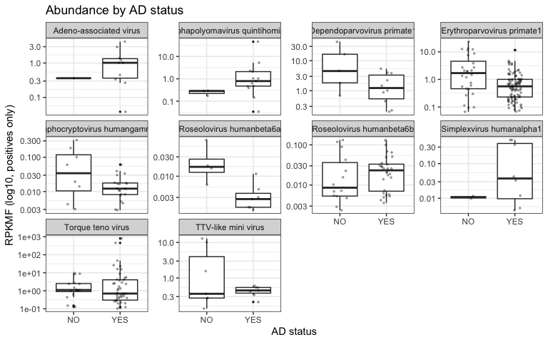

```r
ad_ab_box_p <- ggplot(pos, aes(AD_status, RPKMF)) +
  geom_boxplot(outlier.size = 0.5) +
  geom_jitter(width = 0.15, alpha = 0.3, size = 0.6) +
  scale_y_log10() +
  facet_wrap(~ sp_short, scales = "free_y") +
  labs(x = "AD status", y = "RPKMF (log10, positives only)",
       title = "Abundance by AD status") +
  theme_bw()
ad_ab_box_p
```

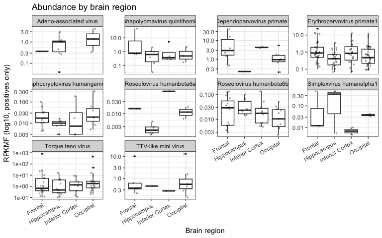

```r
tissue_ab_box_p <- ggplot(pos, aes(tissue, RPKMF)) +
  geom_boxplot(outlier.size = 0.5) +
  geom_jitter(width = 0.15, alpha = 0.3, size = 0.6) +
  scale_y_log10() +
  facet_wrap(~ sp_short, scales = "free_y") +
  labs(x = "Brain region", y = "RPKMF (log10, positives only)",
       title = "Abundance by brain region") +
  theme_bw() +
  theme(axis.text.x = element_text(angle = 30, hjust = 1))
tissue_ab_box_p
```

```r
ggsave(
  here::here("charts/ad_status_ab_box1.pdf"),
  ad_ab_box_p,
  width = 9,
  height = 3.5
)
```

```r
ggsave(
  here::here("charts/tissue_ab_box1.pdf"),
  tissue_ab_box_p,
  width = 9,
  height = 3.5
)
```

### Sensitivity: unconditional tests (zeros included)

Here we repeat the same non-parametric tests but **keep the zeros** (all analysis samples, absence = `RPKMF` 0). These answer the combined question “is overall abundance shifted?”, mixing prevalence and load. Agreement with the conditional results argues the conditioning did not distort the picture; divergence flags that a signal is driven by prevalence rather than load.

```r
# all samples (zeros included); donor-level mean over ALL that donor's samples
donor_abund_all <- pa |>
  group_by(donor, species, sp_short, AD_status, age_at_death) |>
  summarise(mean_RPKMF = mean(RPKMF), .groups = "drop")  # includes zeros
```

```r
# tissue: Kruskal-Wallis on ALL samples (zeros included)
abund_tissue_all <- map_dfr(focal_species$species, function(sp) {
  d  <- filter(pa, species == sp)
  kw <- kruskal.test(RPKMF ~ tissue, data = d)
  tibble(species = gsub("^s__", "", sp), p.value = kw$p.value)
}) |>
  mutate(p.adj = p.adjust(p.value, "BH")) |>
  arrange(p.value)
abund_tissue_all
```

| species | p.value | p.adj |
| --- | --- | --- |
| Adeno-associated virus | 0.002363344 | 0.02363344 |
| Roseolovirus humanbeta6a | 0.036966797 | 0.18483399 |
| Alphapolyomavirus quintihominis | 0.165097928 | 0.55032643 |
| Roseolovirus humanbeta6b | 0.272917336 | 0.61852013 |
| TTV-like mini virus | 0.326989089 | 0.61852013 |
| Erythroparvovirus primate1 | 0.371112077 | 0.61852013 |
| Dependoparvovirus primate1 | 0.527392240 | 0.75341749 |
| Lymphocryptovirus humangamma4 | 0.718928785 | 0.85626271 |
| Simplexvirus humanalpha1 | 0.770636438 | 0.85626271 |
| Torque teno virus | 0.926427509 | 0.92642751 |

```r
# AD: Wilcoxon on donor-level mean abundance (zeros included)
abund_ad_all <- map_dfr(focal_species$species, function(sp) {
  d  <- filter(donor_abund_all, species == sp)
  wt <- wilcox.test(mean_RPKMF ~ AD_status, data = d, exact = FALSE)
  tibble(species = gsub("^s__", "", sp), p.value = wt$p.value)
}) |>
  mutate(p.adj = p.adjust(p.value, "BH")) |>
  arrange(p.value)
abund_ad_all
```

| species | p.value | p.adj |
| --- | --- | --- |
| TTV-like mini virus | 0.1806292 | 0.9660560 |
| Dependoparvovirus primate1 | 0.2888664 | 0.9660560 |
| Adeno-associated virus | 0.3564810 | 0.9660560 |
| Alphapolyomavirus quintihominis | 0.4967348 | 0.9660560 |
| Simplexvirus humanalpha1 | 0.5545070 | 0.9660560 |
| Erythroparvovirus primate1 | 0.6309075 | 0.9660560 |
| Roseolovirus humanbeta6b | 0.6775124 | 0.9660560 |
| Torque teno virus | 0.7728448 | 0.9660560 |
| Lymphocryptovirus humangamma4 | 0.8756534 | 0.9729482 |
| Roseolovirus humanbeta6a | 0.9734924 | 0.9734924 |

```r
# age: Spearman on donor-level mean abundance (zeros included)
abund_age_all <- map_dfr(focal_species$species, function(sp) {
  d  <- filter(donor_abund_all, species == sp)
  ct <- suppressWarnings(
    cor.test(d$age_at_death, d$mean_RPKMF, method = "spearman"))
  tibble(species = gsub("^s__", "", sp), rho = unname(ct$estimate),
         p.value = ct$p.value)
}) |>
  mutate(p.adj = p.adjust(p.value, "BH")) |>
  arrange(p.value)
abund_age_all
```

| species | rho | p.value | p.adj |
| --- | --- | --- | --- |
| Erythroparvovirus primate1 | 0.16164656 | 0.1099389 | 0.6480069 |
| Dependoparvovirus primate1 | -0.14308389 | 0.1576948 | 0.6480069 |
| Roseolovirus humanbeta6a | 0.13152337 | 0.1944021 | 0.6480069 |
| Roseolovirus humanbeta6b | -0.10464611 | 0.3026227 | 0.6759319 |
| Alphapolyomavirus quintihominis | 0.09730898 | 0.3379659 | 0.6759319 |
| Adeno-associated virus | 0.07685600 | 0.4495803 | 0.7493005 |
| Lymphocryptovirus humangamma4 | -0.06359790 | 0.5317164 | 0.7595948 |
| Simplexvirus humanalpha1 | -0.03476178 | 0.7326626 | 0.8416698 |
| TTV-like mini virus | -0.03142313 | 0.7575029 | 0.8416698 |
| Torque teno virus | 0.01857238 | 0.8552204 | 0.8552204 |

```r
# side-by-side: conditional (positives only) vs unconditional (zeros included)
abund_compare_ad <- abund_ad_res |>
  select(species, p.adj_conditional = p.adj) |>
  full_join(abund_ad_all |> select(species, p.adj_unconditional = p.adj),
            by = "species") |>
  arrange(p.adj_unconditional)
abund_compare_ad
```

| species | p.adj_conditional | p.adj_unconditional |
| --- | --- | --- |
| Erythroparvovirus primate1 | 0.09888619 | 0.9660560 |
| Torque teno virus | 0.41510371 | 0.9660560 |
| Dependoparvovirus primate1 | 0.45300030 | 0.9660560 |
| Roseolovirus humanbeta6b | 0.52196059 | 0.9660560 |
| TTV-like mini virus | 1.00000000 | 0.9660560 |
| Alphapolyomavirus quintihominis | NA | 0.9660560 |
| Adeno-associated virus | NA | 0.9660560 |
| Simplexvirus humanalpha1 | NA | 0.9660560 |
| Lymphocryptovirus humangamma4 | 0.45300030 | 0.9729482 |
| Roseolovirus humanbeta6a | NA | 0.9734924 |

# Diversity analysis (vegan)

```r
library(vegan)

sample_meta2 <- sample_meta |> mutate(sample = paste(sample_ID, Pool, sep = "."))

# sample x species abundance matrix (RPKMF), all species, zeros filled
comm_mat <- det |>
  transmute(sample = paste(sample_ID, Pool, sep = "."), species, RPKMF) |>
  tidyr::pivot_wider(names_from = species, values_from = RPKMF, values_fill = 0) |>
  tibble::column_to_rownames("sample")

# add all-zero rows for viral-negative samples, then order to metadata
missing_samples <- setdiff(sample_meta2$sample, rownames(comm_mat))
if (length(missing_samples)) {
  zero_block <- matrix(0, nrow = length(missing_samples), ncol = ncol(comm_mat),
                       dimnames = list(missing_samples, colnames(comm_mat)))
  comm_mat <- rbind(comm_mat, as.data.frame(zero_block))
}
comm_mat <- as.matrix(comm_mat[sample_meta2$sample, , drop = FALSE])

dim(comm_mat)  # samples x species
```

```
[1] 249  50
```

## Alpha diversity

```r
alpha_dt <- sample_meta2 |>
  mutate(richness = specnumber(comm_mat),
         shannon  = diversity(comm_mat, index = "shannon"))

# donor-level (mean across regions) so each donor counts once
alpha_donor <- alpha_dt |>
  group_by(donor, AD_status, age_at_death) |>
  summarise(richness = mean(richness), shannon = mean(shannon), .groups = "drop")

# AD status: Wilcoxon; age: Spearman
alpha_tests <- tibble::tibble(
  metric   = c("shannon", "richness", "shannon", "richness"),
  variable = c("AD_status", "AD_status", "age_at_death", "age_at_death"),
  p.value  = c(
    wilcox.test(shannon  ~ AD_status, data = alpha_donor, exact = FALSE)$p.value,
    wilcox.test(richness ~ AD_status, data = alpha_donor, exact = FALSE)$p.value,
    cor.test(alpha_donor$age_at_death, alpha_donor$shannon,  method = "spearman")$p.value,
    cor.test(alpha_donor$age_at_death, alpha_donor$richness, method = "spearman")$p.value
  )
)
alpha_tests
```

| metric | variable | p.value |
| --- | --- | --- |
| shannon | AD_status | 0.9699853 |
| richness | AD_status | 0.9601573 |
| shannon | age_at_death | 0.1679817 |
| richness | age_at_death | 0.1803955 |

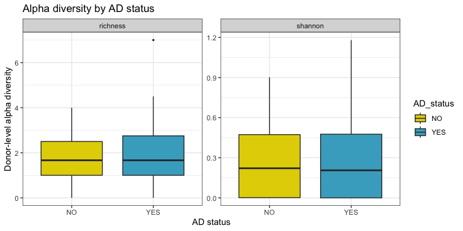

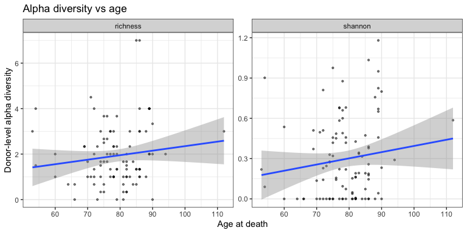

```r
ggsave(
  here::here("charts/age_alpha_scatter1.pdf"),
  alpha_age_p,
  width = 7,
  height = 3
)
```

## Beta diversity (PERMANOVA)

Donor-level community = sum of `RPKMF` across a donor’s regions, converted to relative abundance so total-magnitude effort is removed; `n_regions` still enters the model to absorb richness-effort effects. We use Bray-Curtis (abundance) and Jaccard (presence/absence). Empty (viral-negative) donors are dropped because these distances are undefined for all-zero communities.

```r
set.seed(1)

donor_map  <- setNames(sample_meta2$donor, sample_meta2$sample)
donor_comm <- rowsum(comm_mat, group = donor_map[rownames(comm_mat)])
n_reg      <- table(donor_map[rownames(comm_mat)])

keep <- rowSums(donor_comm) > 0            # drop viral-negative donors
dc   <- donor_comm[keep, , drop = FALSE]

md <- sample_meta2 |>
  distinct(donor, AD_status, age_at_death) |>
  mutate(n_regions = as.integer(n_reg[donor]))
md <- md[match(rownames(dc), md$donor), ]

cat("donors used for beta diversity:", nrow(dc),
    "  (dropped", sum(!keep), "viral-negative)\n")
```

```
donors used for beta diversity: 94   (dropped 5 viral-negative)
```

```r
dc_rel <- decostand(dc, method = "total")  # relative abundance per donor
bc     <- vegdist(dc_rel, method = "bray")
jac    <- vegdist(dc > 0, method = "jaccard")

# marginal PERMANOVA (each term adjusted for the others)
adonis_bray <- adonis2(bc ~ n_regions + AD_status + age_at_death,
                       data = md, by = "margin", permutations = 999)
adonis_jac  <- adonis2(jac ~ n_regions + AD_status + age_at_death,
                       data = md, by = "margin", permutations = 999)
adonis_bray
```

```
Permutation test for adonis under reduced model
Marginal effects of terms
Permutation: free
Number of permutations: 999

adonis2(formula = bc ~ n_regions + AD_status + age_at_death, data = md, permutations = 999, by = "margin")
             Df SumOfSqs      R2      F Pr(>F)
n_regions     1    0.521 0.01642 1.5382  0.123
AD_status     1    0.146 0.00460 0.4313  0.933
age_at_death  1    0.469 0.01479 1.3852  0.196
Residual     90   30.464 0.96079
Total        93   31.707 1.00000
```

```r
adonis_jac
```

```
Permutation test for adonis under reduced model
Marginal effects of terms
Permutation: free
Number of permutations: 999

adonis2(formula = jac ~ n_regions + AD_status + age_at_death, data = md, permutations = 999, by = "margin")
             Df SumOfSqs      R2      F Pr(>F)
n_regions     1    1.025 0.03101 2.9269  0.001 ***
AD_status     1    0.211 0.00638 0.6018  0.886
age_at_death  1    0.226 0.00684 0.6455  0.840
Residual     90   31.521 0.95361
Total        93   33.054 1.00000
---
Signif. codes:  0 ‘***’ 0.001 ‘**’ 0.01 ‘*’ 0.05 ‘.’ 0.1 ‘ ’ 1
```

**Dispersion check (important here).** PERMANOVA can report a spurious “location” difference when groups have unequal size *and* unequal within-group dispersion - exactly our situation (many AD vs few controls). `betadisper` tests whether the groups differ in spread; a significant result means any PERMANOVA signal should be interpreted cautiously.

```r
set.seed(1)
bd <- betadisper(bc, md$AD_status)
permutest(bd, permutations = 999)
```

```
Permutation test for homogeneity of multivariate dispersions
Permutation: free
Number of permutations: 999

Response: Distances
          Df Sum Sq  Mean Sq      F N.Perm Pr(>F)
Groups     1 0.0002 0.000207 0.0036    999   0.95
Residuals 92 5.3410 0.058054
```

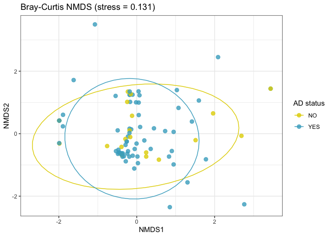

```r
set.seed(1)
nmds <- metaMDS(dc_rel, distance = "bray", trymax = 50, trace = 0)

nmds_scores <- as.data.frame(vegan::scores(nmds, display = "sites")) |>
  tibble::rownames_to_column("donor") |>
  left_join(md, by = "donor")

ad_nmds_p <- ggplot(nmds_scores, aes(NMDS1, NMDS2, color = AD_status)) +
  geom_point(size = 2.5, alpha = 0.8) +
  stat_ellipse() +
  scale_color_manual(values = c(
    "#E2D200", "#46ACC8"
  )) +
  labs(title = sprintf("Bray-Curtis NMDS (stress = %.3f)", nmds$stress),
       colour = "AD status") +
  theme_bw()
ad_nmds_p
```

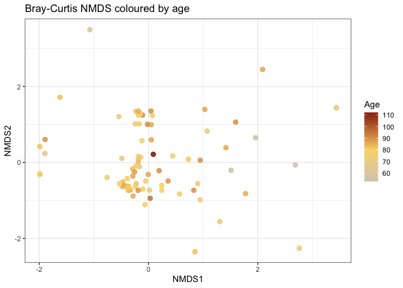

```r
age_nmds_p <- ggplot(nmds_scores, aes(NMDS1, NMDS2, colour = age_at_death)) +
  geom_point(size = 2.5, alpha = 0.9) +
  scale_color_gradient2(low = "grey80", mid = "#FAD77B", high = "#972D15", midpoint = 80) +
  labs(title = "Bray-Curtis NMDS coloured by age", colour = "Age") +
  theme_bw()
age_nmds_p
```

```r
ggsave(
  here::here("charts/age_NMDS1.pdf"),
  age_nmds_p,
  width = 5,
  height = 4
)
```

# Power / sample-size analysis (for future designs)

The AD and age effects are tested at the **donor** level (the effective sample size is the number of donors, not samples, because brain regions within a donor are repeated measures). The bottleneck is the **imbalance**: many AD donors but few non-AD controls. We quantify this two ways below.

```r
set.seed(1)

# effective (donor-level) group sizes actually used for the AD contrast
donor_tab <- sample_meta |> distinct(donor, AD_status) |> count(AD_status)
donor_tab
n_AD    <- donor_tab$n[donor_tab$AD_status == "YES"]
n_ctrl  <- donor_tab$n[donor_tab$AD_status == "NO"]
c(n_AD = n_AD, n_ctrl = n_ctrl)

# Monte-Carlo power for a Fisher's exact test comparing two prevalences.
# p_ctrl / p_ad = detection prevalence in each donor group.
power_fisher <- function(p_ctrl, p_ad, n_ctrl, n_ad,
                         nsim = 1000, alpha = 0.05) {
  mean(replicate(nsim, {
    x1 <- rbinom(1, n_ctrl, p_ctrl)
    x2 <- rbinom(1, n_ad,   p_ad)
    m  <- matrix(c(x1, n_ctrl - x1, x2, n_ad - x2), nrow = 2)
    fisher.test(m)$p.value < alpha
  }))
}
```

[output not shown]

## Minimum detectable effect for the AD contrast (current cohort)

For a range of baseline (control) prevalences spanning our focal species, what odds ratio would we have **80% power** to detect with the current 23 control vs 76 AD donors? We show it at a nominal `alpha = 0.05` and at a multiplicity-adjusted `alpha = 0.005` (~Bonferroni for 10 species).

```r
inv_or <- function(p1, or) (or * p1 / (1 - p1)) / (1 + or * p1 / (1 - p1))  # p2 from OR

mde_ad <- tidyr::crossing(
  p_ctrl = c(0.10, 0.25, 0.50),
  alpha  = c(0.05, 0.005),
  OR     = seq(1.5, 30, by = 0.5)
) |>
  mutate(p_ad  = inv_or(p_ctrl, OR),
         power = purrr::pmap_dbl(list(p_ctrl, p_ad, alpha),
                    ~ power_fisher(..1, ..2, n_ctrl, n_AD,
                                   nsim = 800, alpha = ..3))) |>
  group_by(p_ctrl, alpha) |>
  summarise(min_detectable_OR = {
    hit <- OR[power >= 0.80]
    if (length(hit)) min(hit) else NA_real_
  }, .groups = "drop")
mde_ad
```

[output not shown]

## Power vs cohort balance (design curve)

Holding a plausible effect fixed (control prevalence 25% vs AD 50%, OR = 3), how does power grow as we recruit **more control donors**? The current design sits at the current number of control donors (dotted vertical line in the plot).

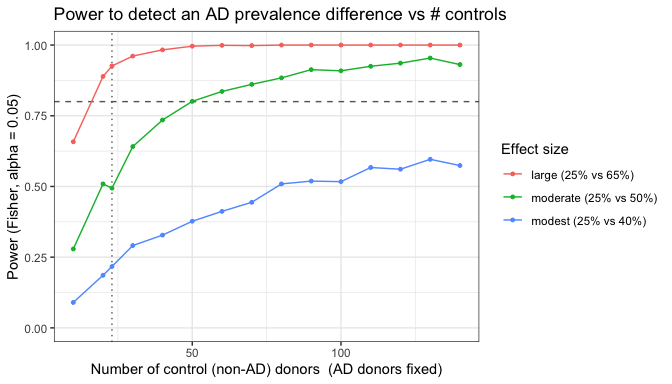

## Power for the age (continuous) association

Age is tested by correlation at the donor level. The minimum detectable |correlation| at 80% power depends on the number of donors contributing (all donors for presence-linked tests; only *positive* donors for the abundance-conditional Spearman test).

```r
# closed-form detectable Pearson/Spearman r via Fisher z-transform
detectable_r <- function(n, power = 0.80, alpha = 0.05) {
  if (n <= 4) return(NA_real_)
  z <- (qnorm(1 - alpha / 2) + qnorm(power)) / sqrt(n - 3)
  tanh(z)
}

n_donor_total <- n_distinct(sample_meta$donor)

# effective N for each abundance-age test = positive donors per species
age_power <- donor_abund |>
  count(sp_short, name = "n_pos_donor") |>
  mutate(min_detectable_rho = round(vapply(n_pos_donor, detectable_r, numeric(1)), 2)) |>
  arrange(desc(n_pos_donor))

cat("All-donor detectable |r| (n =", n_donor_total, "):",
    round(detectable_r(n_donor_total), 2), "\n")
age_power
```

[output not shown]